# Tarea 4 Big Data-Sigma

Shanthal Chavarría

2021-07-30

# 1. **[20 puntos]** Usando la tabla de datos `MuestraCredito5000.csv`, la cual contiene información de los créditos de los clientes de un banco, genere una tabla simbólica usando las variables `GradoAcademico` y `BuenPagador` como concepto, y luego realice lo siguiente:

```r
datos <- read.table("datos/MuestraCredito5000V2.csv", sep = ";", ".", header = T,
    stringsAsFactors = T)

datos$CoefCreditoAvaluo <- as.factor(datos$CoefCreditoAvaluo)

datos$IngresoNeto <- as.factor(datos$IngresoNeto)
```

## a) Genere una tabla simbólica usando la variable `BuenPagador` como concepto.

```r
library(RSDA)

datos_sym <- classic.to.sym(x = datos, concept = BuenPagador)

datos_sym
```

| MontoCredito | IngresoNeto | CoefCreditoAvaluo | MontoCuota | GradoAcademico |
| --- | --- | --- | --- | --- |
| [10,000.00 : 294,735.00] |  |  |  |  |
| [10,000.00 : 299,082.00] |  |  |  |  |

## b) Imprima y gráfique la tabla simbólica.

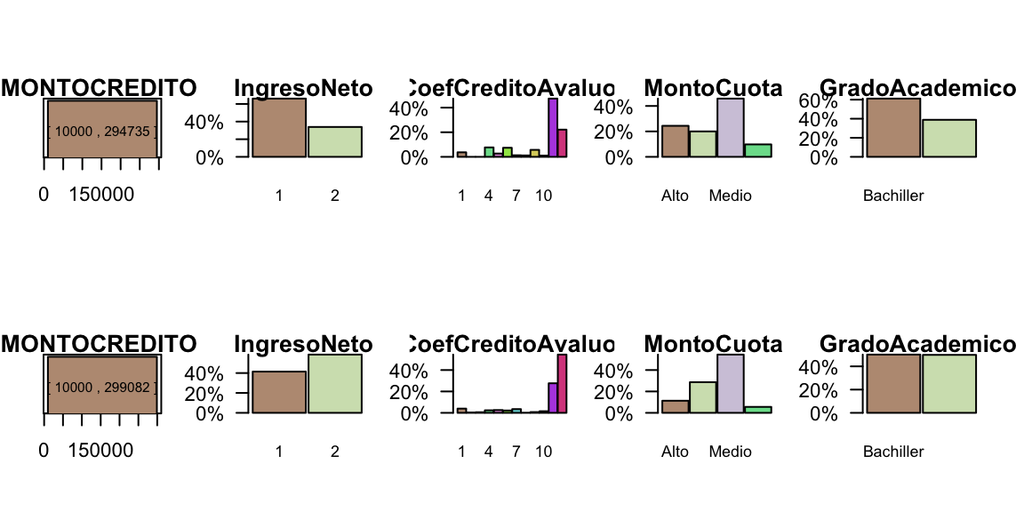

```r
plot(datos_sym)
```

```r
attr(datos_sym, "concept")
```

```
[1] "No" "Si"
```

## c) Indique las características que definen a un buen y a un mal pagador.

# 2. **[40 puntos]** La tabla `painters` del paquete `MASS` se muestra parcialmente a continuación:

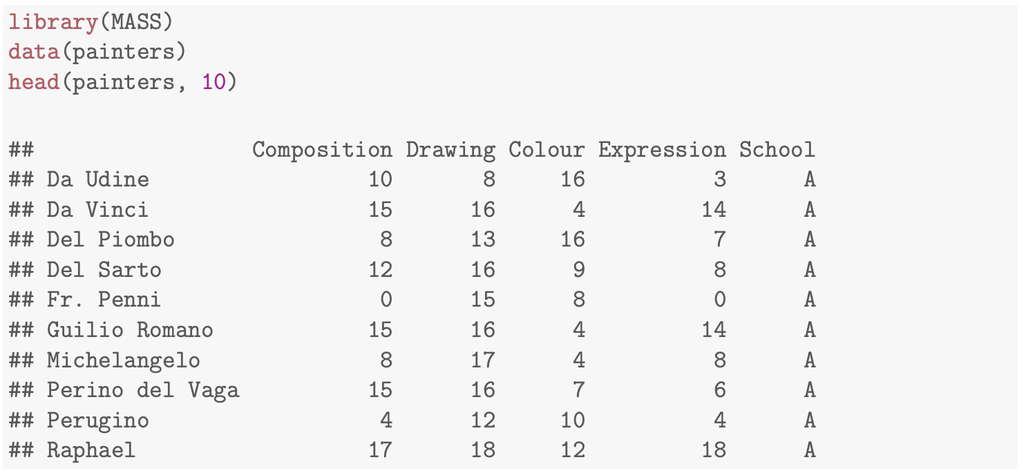

En esta tabla de datos expertos evaluaron de 0 a 20 a los principales pintores de la historia en Calidad de Composición (`Composition`), Calidad de Trazo (`Drawing`), Uso del Color (`Colour`) y Expresión (`Expression`). Esta tabla también contiene una variable categórica `School` que ubica a cada uno de los pintores en sus respectivas escuelas de pintura: **A: Renaissance; B: Mannerist; C: Seicento; D: Venetian; E: Lombard; F: Sixteenth Century; G: Seventeenth Century y H: French**. Con esta tabla de datos realice lo siguiente:

## a) Construya una tabla simbólica usando la variable `School` como concepto.

```r
library(MASS)
data(painters)
head(painters)
```

|  | Composition | Drawing | Colour | Expression | School |
| --- | --- | --- | --- | --- | --- |
| Da Udine | 10 | 8 | 16 | 3 | A |
| Da Vinci | 15 | 16 | 4 | 14 | A |
| Del Piombo | 8 | 13 | 16 | 7 | A |
| Del Sarto | 12 | 16 | 9 | 8 | A |
| Fr. Penni | 0 | 15 | 8 | 0 | A |
| Guilio Romano | 15 | 16 | 4 | 14 | A |

```r
painters_sym <- classic.to.sym(x = painters, concept = School)
painters_sym
```

| Composition | Drawing | Colour | Expression |
| --- | --- | --- | --- |
| [0.00 : 17.00] | [8.00 : 18.00] | [4.00 : 16.00] | [0.00 : 18.00] |
| [10.00 : 15.00] | [13.00 : 15.00] | [5.00 : 10.00] | [6.00 : 10.00] |
| [10.00 : 16.00] | [10.00 : 15.00] | [0.00 : 12.00] | [2.00 : 13.00] |
| [4.00 : 15.00] | [6.00 : 15.00] | [14.00 : 18.00] | [0.00 : 6.00] |
| [6.00 : 18.00] | [6.00 : 17.00] | [9.00 : 16.00] | [0.00 : 17.00] |
| [4.00 : 9.00] | [6.00 : 15.00] | [6.00 : 16.00] | [4.00 : 13.00] |
| [10.00 : 18.00] | [6.00 : 14.00] | [10.00 : 17.00] | [6.00 : 17.00] |
| [10.00 : 16.00] | [8.00 : 17.00] | [4.00 : 8.00] | [4.00 : 16.00] |

## b) Grafique toda la tabla resultante.

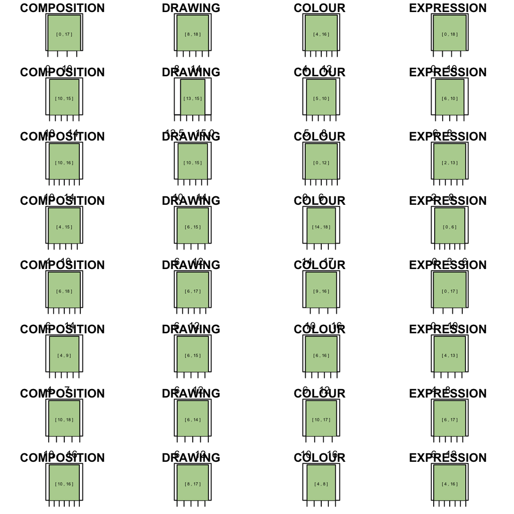

```r
plot(painters_sym)
```

## c) Grafique las primeras 4 filas de la tabla resultante.

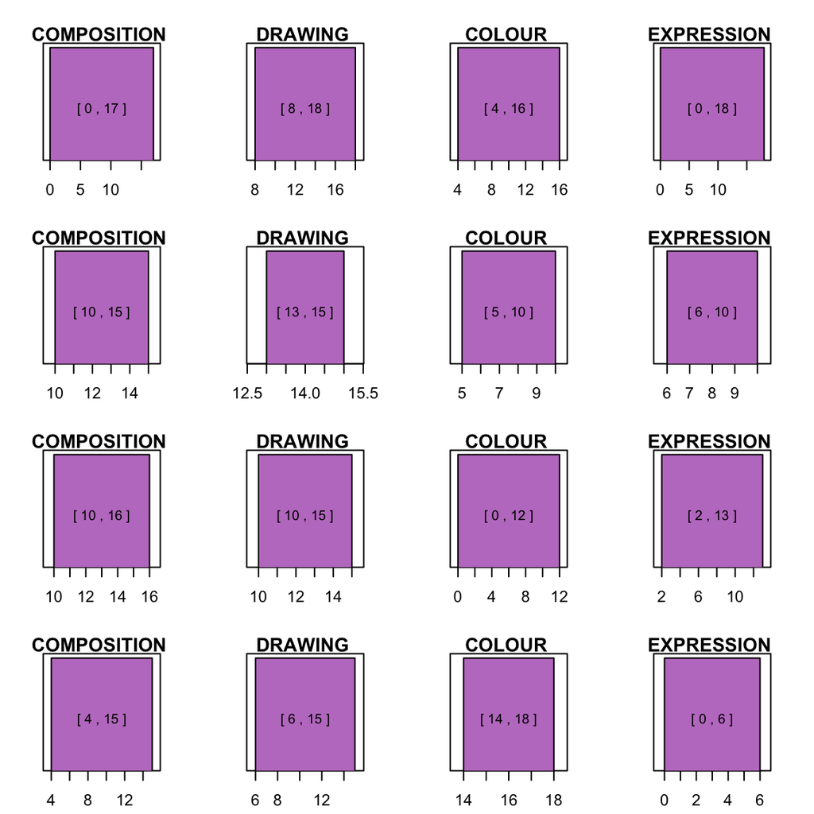

```r
plot(head(painters_sym, 4))
```

## d) Para todas las variables calcule la Media Simbólica, la Mediana Simbólica, la Varianza, la Desviación Estándar Simbólicas y calcule la Correlación Simbólica entre dos pares de variables.

### Media

```r
lapply(painters_sym, mean, method = "interval")
```

```
$Composition
<symbolic_interval[1]>
[1] [6.75 : 15.50]

$Drawing
<symbolic_interval[1]>
[1] [7.88 : 15.75]

$Colour
<symbolic_interval[1]>
[1] [6.50 : 14.12]

$Expression
<symbolic_interval[1]>
[1] [2.75 : 13.75]
```

### Mediana

```r
lapply(painters_sym, median, method = "interval")
```

```
$Composition
<symbolic_interval[1]>
[1] [8.00 : 16.00]

$Drawing
<symbolic_interval[1]>
[1] [7.00 : 15.00]

$Colour
<symbolic_interval[1]>
[1] [5.50 : 16.00]

$Expression
<symbolic_interval[1]>
[1] [3.00 : 14.50]
```

### Varianza

```r
lapply(painters_sym, var, method = "interval")
```

```
$Composition
<symbolic_interval[1]>
[1] [14.79 : 8.29]

$Drawing
<symbolic_interval[1]>
[1] [6.41 : 1.93]

$Colour
<symbolic_interval[1]>
[1] [18.86 : 13.27]

$Expression
<symbolic_interval[1]>
[1] [6.79 : 17.07]
```

### Desviación Estándar

```r
lapply(painters_sym, sd, method = "interval")
```

```
$Composition
<symbolic_interval[1]>
[1] [3.85 : 2.88]

$Drawing
<symbolic_interval[1]>
[1] [2.53 : 1.39]

$Colour
<symbolic_interval[1]>
[1] [4.34 : 3.64]

$Expression
<symbolic_interval[1]>
[1] [2.60 : 4.13]
```

### Correlación Simbólica

```r
cor(painters_sym$Drawing, painters_sym$Colour, method = "billard")
```

```
[1] -0.9299924
```

## e) Realice un gráfico de tipo Radar para las filas (conceptos) 3 y 4 de la tabla resultante. Interprete.

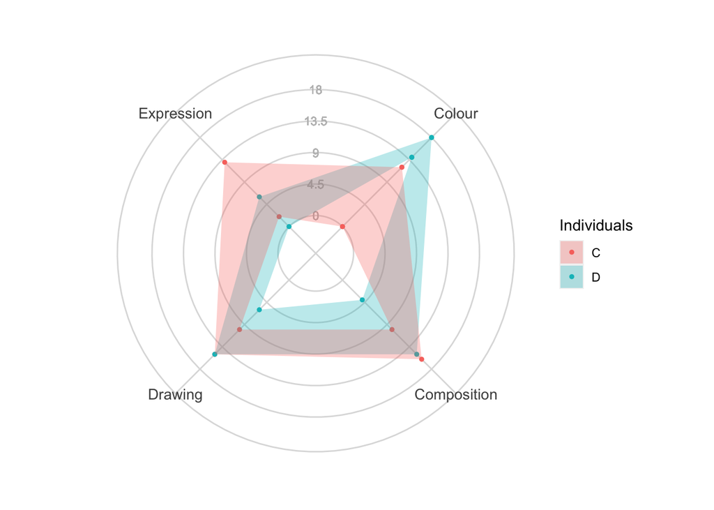

```r
library(ggpolypath)
sym.radar.plot(painters_sym[c(3, 4), ])
```

## f) Efectúe un Análisis en Componentes Principales, interprete las agrupaciones, las correlaciones, la sobreposición de gráficos, para esto realice un ACP usando la opción `method='classic'` y luego para interpretar la variabilidad ejecute el ACP con la opción `method='centers'`.

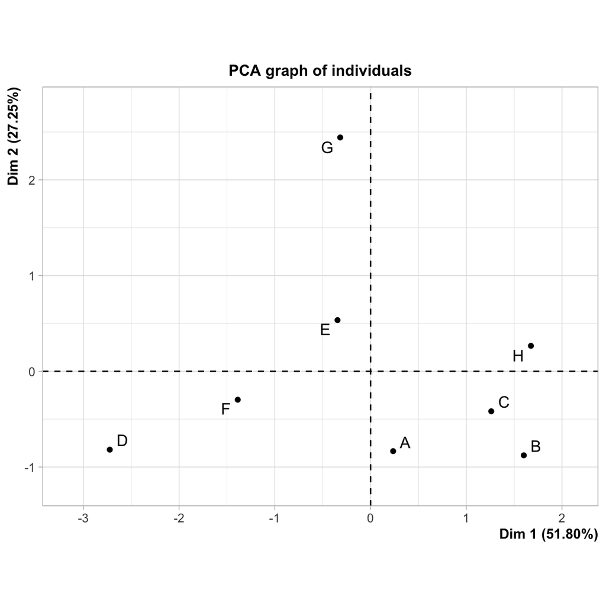

```r
res <- sym.pca(painters_sym, "classic")

plot(res, choix = "ind")
```

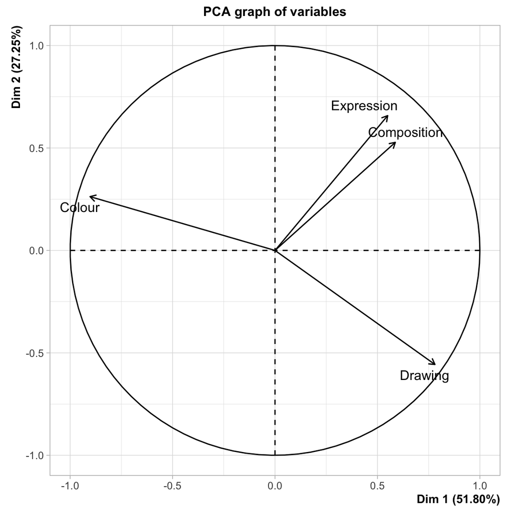

```r
plot(res, choix = "var")
```

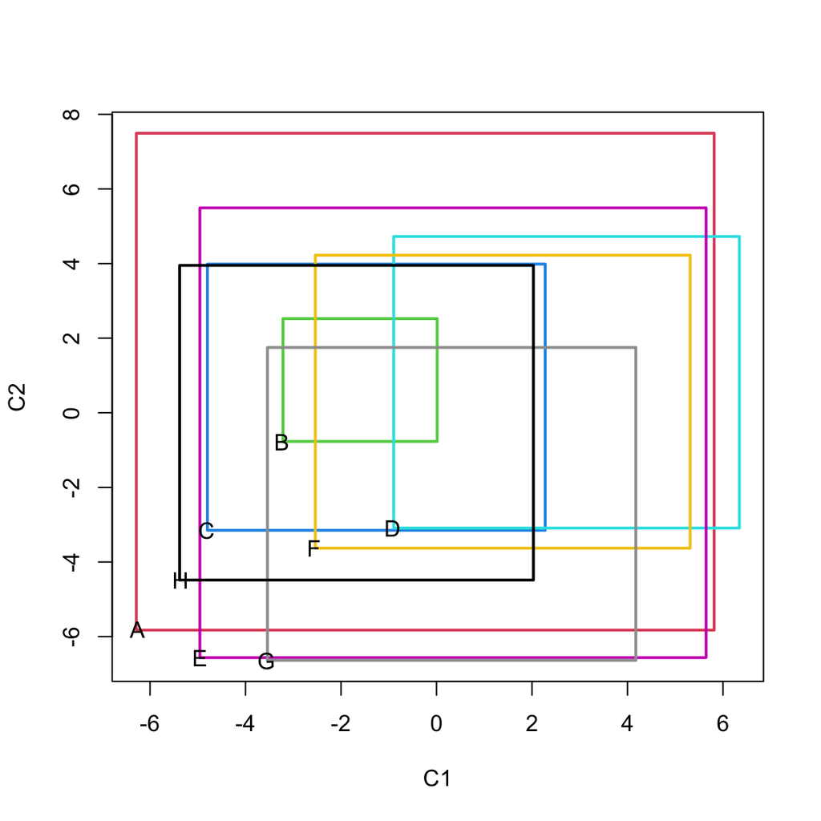

```r
res <- sym.pca(painters_sym, "centers")

plot(res, choix = "ind")
```

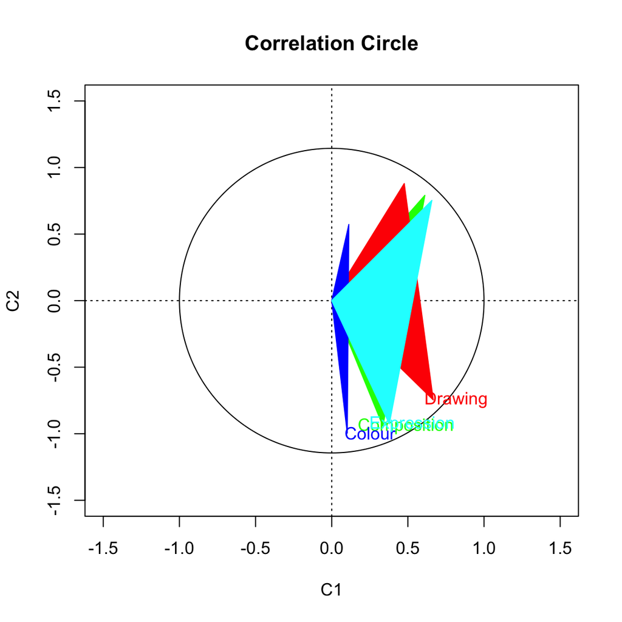

```r
plot(res, choix = "var")
```